# Project: Investigating Movie Dataset

- Introduction
- Data Wrangling
- Exploratory Data Analysis
- Conclusions
- References

## Introduction

This data set contains information about 10,000 movies collected from The Movie Database (TMDb), including user ratings and revenue. The data set covers a 56 years interval with a wide range of genres.

The dataset contains information like the movies popularity rating, the budget and revenue, genre, release date, vote count, average vote, the cast, director, title and production company.

I intend to establish indicators to look out for in a movie that generates high revenue and also establish how the popular movie geners are changing over the tine frame of interest.

## QUESTIONS:

1. Which genres are most popular from year to year?
2. What kinds of properties are associated with movies that have high revenues?

```python
# import important libraries for this analysis
import pandas as pd
import numpy as np
import matplotlib.pyplot as plt
```

```python
# load data and inspect dataframe
df = pd.read_csv('tmdb-movies.csv')
df.head(1)
```

|  | id | imdb_id | popularity | budget | revenue | original_title | cast | homepage | director | tagline | ... | overview | runtime | genres | production_companies | release_date | vote_count | vote_average | release_year | budget_adj | revenue_adj |
| --- | --- | --- | --- | --- | --- | --- | --- | --- | --- | --- | --- | --- | --- | --- | --- | --- | --- | --- | --- | --- | --- |
| 0 | 135397 | tt0369610 | 32.985763 | 150000000 | 1513528810 | Jurassic World | Chris Pratt\|Bryce Dallas Howard\|Irrfan Khan\|Vi... | http://www.jurassicworld.com/ | Colin Trevorrow | The park is open. | ... | Twenty-two years after the events of Jurassic ... | 124 | Action\|Adventure\|Science Fiction\|Thriller | Universal Studios\|Amblin Entertainment\|Legenda... | 6/9/15 | 5562 | 6.5 | 2015 | 1.379999e+08 | 1.392446e+09 |

1 rows × 21 columns

● Certain columns, like ‘cast’ and ‘genres’, contain multiple values separated by pipe (|) characters.

● The final two columns ending with “_adj” show the budget and revenue of the associated movie in terms of 2010 dollars, accounting for inflation over time.

## Data Wrangling

The following steps are observed for the data wrangling process. This is done to obtain a uniform dataset containing only relevant information required to arrive at the answers to the questions we asked about the data.

### STEPS

> 1. Removing features of the data not needed to answer the questions we asked. Examples are id, imb_id, the budget and revenue data without correction for time value to money, movie homepage, etc.
> 2. Checking for null values in different columns. If any is found, we check if they can be manufactured depending on the nature of the data or decide to removing the records containing null values, this is also dependent on the amount of records with null values.
> 3. Checking and removing duplicated records.
1. **REMOVING UNIMPORTANT COLUMNS**

```python
# drop features that are not useful to answer the two questions posed for this analysis.

df.drop(['id', 'imdb_id', 'budget', 'revenue', 'original_title', 'cast', 'homepage', 'director', 'tagline',  'keywords', 'overview', 'production_companies', 'release_date'], axis = 1, inplace = True)
df.head()
```

|  | popularity | runtime | genres | vote_count | vote_average | release_year | budget_adj | revenue_adj |
| --- | --- | --- | --- | --- | --- | --- | --- | --- |
| 0 | 32.985763 | 124 | Action\|Adventure\|Science Fiction\|Thriller | 5562 | 6.5 | 2015 | 1.379999e+08 | 1.392446e+09 |
| 1 | 28.419936 | 120 | Action\|Adventure\|Science Fiction\|Thriller | 6185 | 7.1 | 2015 | 1.379999e+08 | 3.481613e+08 |
| 2 | 13.112507 | 119 | Adventure\|Science Fiction\|Thriller | 2480 | 6.3 | 2015 | 1.012000e+08 | 2.716190e+08 |
| 3 | 11.173104 | 136 | Action\|Adventure\|Science Fiction\|Fantasy | 5292 | 7.5 | 2015 | 1.839999e+08 | 1.902723e+09 |
| 4 | 9.335014 | 137 | Action\|Crime\|Thriller | 2947 | 7.3 | 2015 | 1.747999e+08 | 1.385749e+09 |

```python
# dataframe information after features important for this analysis have been selected
df.info()
```

```
<class 'pandas.core.frame.DataFrame'>
RangeIndex: 10866 entries, 0 to 10865
Data columns (total 8 columns):
 #   Column        Non-Null Count  Dtype
---  ------        --------------  -----
 0   popularity    10866 non-null  float64
 1   runtime       10866 non-null  int64
 2   genres        10843 non-null  object
 3   vote_count    10866 non-null  int64
 4   vote_average  10866 non-null  float64
 5   release_year  10866 non-null  int64
 6   budget_adj    10866 non-null  float64
 7   revenue_adj   10866 non-null  float64
dtypes: float64(4), int64(3), object(1)
memory usage: 679.2+ KB
```

1. **CHECKING AND REMOVING NULL VALUES**

```python
# check each feature for null values
df.isna().sum()
```

```
popularity       0
runtime          0
genres          23
vote_count       0
vote_average     0
release_year     0
budget_adj       0
revenue_adj      0
dtype: int64
```

```python
# drop any entry with a null value in any of the feature
df.dropna(axis=0, how='any', inplace=True)
```

```python
# confirm if all entries with null values have been removed from dataframe
df.isna().sum()
```

```
popularity      0
runtime         0
genres          0
vote_count      0
vote_average    0
release_year    0
budget_adj      0
revenue_adj     0
dtype: int64
```

1. **CHECKING AND REMOVING DUPLICATED VALUES**

```python
# check for the presence and number of duplicate entries in dataframe
df.duplicated().sum()
```

```
1
```

```python
# remove all duplicated entries in dataframe
df.drop_duplicates(inplace=True)
```

```python
# final structure of cleaned dataframe ready for analysis
df.info()
```

```
<class 'pandas.core.frame.DataFrame'>
Int64Index: 10842 entries, 0 to 10865
Data columns (total 8 columns):
 #   Column        Non-Null Count  Dtype
---  ------        --------------  -----
 0   popularity    10842 non-null  float64
 1   runtime       10842 non-null  int64
 2   genres        10842 non-null  object
 3   vote_count    10842 non-null  int64
 4   vote_average  10842 non-null  float64
 5   release_year  10842 non-null  int64
 6   budget_adj    10842 non-null  float64
 7   revenue_adj   10842 non-null  float64
dtypes: float64(4), int64(3), object(1)
memory usage: 762.3+ KB
```

```python
# number of unique values in each feature of the dataframe
df.nunique()
```

```
popularity      10791
runtime           246
genres           2039
vote_count       1289
vote_average       72
release_year       56
budget_adj       2613
revenue_adj      4840
dtype: int64
```

## Exploratory Data Analysis between variables.

### Research Question 1 (Which genres are most popular from year to year?)

```python
# spill genres entries into different geners
# this would enable us know the total number of unique genres in the dataframe

df_genres = df['genres'].str.split(pat = '|', n=-1, expand = True)
df_genres.nunique()
```

```
0    20
1    20
2    20
3    20
4    19
dtype: int64
```

From the results above, there are 20 unique genres in the dataframe

```python
# make a sorted list of all the genres contained in the dataframe

genre_types = df_genres[0].unique()
genre_types.sort()
genre_types
```

```
array(['Action', 'Adventure', 'Animation', 'Comedy', 'Crime',
       'Documentary', 'Drama', 'Family', 'Fantasy', 'Foreign', 'History',
       'Horror', 'Music', 'Mystery', 'Romance', 'Science Fiction',
       'TV Movie', 'Thriller', 'War', 'Western'], dtype=object)
```

```python
# Construct a dataframe containing the different genres and their mean popularity rating for different years

genre_series = {}

for genre in genre_types:
    # Create a dataframe of all entries with the genre currently being iterated
    df_byGenres = df[df.genres.str.contains(genre, case=False)]

    # Create a pandas series of the mean popularity for each year.
    df_popularityByYear = df_byGenres.groupby('release_year').popularity.mean()

    genre_series.update({genre:df_popularityByYear})

df_genresByYear = pd.DataFrame(genre_series)
df_genresByYear
```

| release_year | Action | Adventure | Animation | Comedy | Crime | Documentary | Drama | Family | Fantasy | Foreign | History | Horror | Music | Mystery | Romance | Science Fiction | TV Movie | Thriller | War | Western |
| --- | --- | --- | --- | --- | --- | --- | --- | --- | --- | --- | --- | --- | --- | --- | --- | --- | --- | --- | --- | --- |
| 1960 | 0.590724 | 0.700981 | NaN | 0.396000 | 0.346479 | NaN | 0.566305 | 0.278064 | 0.428247 | 0.194948 | 0.412364 | 0.591450 | 0.423531 | NaN | 0.541227 | 0.327905 | NaN | 0.811910 | 0.225863 | 0.567759 |
| 1961 | 0.365913 | 0.767323 | 2.631987 | 0.679838 | 0.806519 | NaN | 0.432233 | 0.755722 | 0.154073 | 0.113651 | 0.334463 | 0.254578 | 0.564748 | 0.712793 | 0.426036 | 0.274103 | NaN | NaN | 0.531184 | 0.210021 |
| 1962 | 0.708945 | 0.942513 | NaN | 0.273183 | 0.472816 | NaN | 0.392000 | 0.323463 | 0.235542 | 0.235542 | 0.600060 | 0.179368 | 0.323933 | 0.259220 | 0.365621 | 0.179212 | NaN | 0.760582 | 0.506162 | 0.414180 |
| 1963 | 0.951729 | 0.728487 | 2.180410 | 0.444481 | 0.552367 | NaN | 0.322448 | 0.852632 | 0.214071 | 0.351647 | 0.481618 | 0.376901 | NaN | 0.421033 | 0.399573 | 0.467835 | NaN | 0.719929 | 0.664326 | 0.246957 |
| 1964 | 0.813087 | 0.736431 | 0.445746 | 0.491229 | 0.261690 | NaN | 0.364818 | 0.878298 | 0.599791 | 0.152209 | 0.316377 | 0.189650 | 0.753799 | 0.308091 | 0.221586 | 0.226636 | NaN | 0.622580 | 0.930959 | 0.127679 |
| 1965 | 0.451373 | 0.581820 | 0.600975 | 0.358721 | 0.387277 | NaN | 0.305288 | 0.662713 | NaN | 0.004770 | 0.173948 | 0.124838 | 0.968850 | 0.209204 | 0.622780 | 0.101956 | 0.600975 | 0.343072 | 0.312124 | 0.191833 |
| 1966 | 0.263347 | 0.293593 | 0.585717 | 0.323658 | 0.340702 | 0.080598 | 0.339766 | 0.398896 | 0.424771 | 0.361556 | 0.335649 | 0.094397 | NaN | 0.234951 | 0.351903 | 0.317790 | NaN | 0.273869 | 0.290459 | 0.244657 |
| 1967 | 0.723570 | 1.025547 | 1.348805 | 0.434822 | 0.538359 | 0.095101 | 0.511467 | 0.962015 | 0.187009 | NaN | NaN | 0.289964 | 0.151540 | 0.401409 | 0.417445 | 0.187465 | NaN | 0.701979 | 0.485288 | 0.189740 |
| 1968 | 0.365562 | 1.109147 | 0.302135 | 0.329548 | 0.555919 | NaN | 0.377322 | 0.426263 | 0.445584 | NaN | 0.481894 | 0.558404 | 0.515485 | 1.519456 | 0.260356 | 1.343642 | NaN | 0.555919 | 0.316055 | 0.621202 |
| 1969 | 0.539976 | 0.748933 | 0.292274 | 0.270504 | 0.948020 | NaN | 0.489887 | 0.402277 | 0.204098 | NaN | 0.718985 | 0.141028 | 0.404251 | 0.567962 | 0.288267 | 0.172540 | 0.528660 | 0.871283 | 0.316193 | 0.509225 |
| 1970 | 0.241650 | 0.702472 | 1.127719 | 0.444703 | 0.299802 | 0.213653 | 0.316588 | 0.893289 | 0.312537 | 0.092150 | 0.313615 | 0.273144 | 0.221343 | 0.435701 | 0.317923 | 0.425457 | 0.318475 | 0.254104 | 0.471745 | 0.240522 |
| 1971 | 0.600479 | 0.646932 | 0.630778 | 0.397402 | 0.456364 | NaN | 0.403105 | 1.530722 | 1.530722 | NaN | 0.184290 | 0.174742 | 0.291077 | 0.384909 | 0.375123 | 1.217891 | 0.176973 | 0.504428 | 0.197980 | 0.331972 |
| 1972 | 0.324774 | 0.465044 | 0.198304 | 0.271911 | 1.072768 | 0.265169 | 0.695491 | 0.204575 | 0.432033 | NaN | NaN | 0.187596 | 0.467107 | 0.291045 | 0.422425 | 0.455735 | NaN | 0.351444 | NaN | 0.315965 |
| 1973 | 0.564331 | 0.730942 | 0.956526 | 0.436991 | 0.462433 | 0.021941 | 0.475880 | 0.813364 | 0.383880 | NaN | 0.525313 | 0.419544 | 0.549206 | 0.325677 | 0.551469 | 0.564470 | 0.143165 | 0.611568 | NaN | 0.446250 |
| 1974 | 0.419121 | 0.465579 | 0.218245 | 0.441918 | 0.605785 | 0.101016 | 0.525940 | 0.261080 | 0.426518 | NaN | 0.441423 | 0.305207 | 0.316938 | 0.702035 | 0.361984 | 0.471948 | 0.441423 | 0.455492 | 0.029670 | 0.384220 |
| 1975 | 0.267063 | 0.880297 | 0.032936 | 0.600482 | 0.226363 | 0.125881 | 0.558743 | 0.310580 | 0.863640 | NaN | 0.293670 | 0.670227 | 0.686863 | 0.319819 | 0.598853 | 0.427785 | NaN | 0.457069 | 0.778775 | 0.178887 |
| 1976 | 0.405703 | 0.515526 | NaN | 0.322486 | 0.707249 | 0.126140 | 0.588649 | 0.175857 | 0.177713 | 0.042353 | 0.653132 | 0.432292 | 0.159636 | 0.426270 | 0.356692 | 0.546678 | 0.283119 | 0.503123 | 0.432984 | 0.414412 |
| 1977 | 1.419319 | 1.407146 | 0.844980 | 0.490214 | 0.407847 | 0.520725 | 0.422307 | 0.746973 | 0.585984 | NaN | 0.536451 | 0.185383 | 0.532732 | 0.125376 | 0.664996 | 1.381872 | NaN | 0.444694 | 0.636447 | 0.241629 |
| 1978 | 0.480816 | 0.447605 | 0.361015 | 0.407330 | 0.598354 | 0.145181 | 0.352573 | 0.422994 | 0.458115 | 0.108201 | 0.437522 | 0.389210 | 0.679805 | 0.308120 | 0.275341 | 0.322391 | 0.258473 | 0.446494 | 0.448942 | 0.063184 |
| 1979 | 1.410014 | 0.986590 | 0.147473 | 0.481970 | 0.373405 | NaN | 0.474715 | 0.196968 | NaN | NaN | 0.617482 | 0.731313 | 0.472118 | 0.673042 | 0.375945 | 1.259799 | NaN | 0.829547 | 0.893133 | 0.257197 |
| 1980 | 0.594729 | 0.788612 | NaN | 0.438154 | 0.416538 | NaN | 0.374680 | 0.362390 | 0.412032 | 0.367193 | 0.344123 | 0.446982 | 0.513350 | 0.249771 | 0.561402 | 0.897143 | 0.646441 | 0.333288 | 0.232843 | 0.300109 |
| 1981 | 0.713769 | 0.875815 | 0.798668 | 0.401033 | 0.247597 | 0.059450 | 0.359002 | 0.427657 | 0.304373 | NaN | 0.505874 | 0.309662 | 0.154089 | 0.214646 | 0.474171 | 0.496963 | 0.089413 | 0.368905 | 0.392647 | NaN |
| 1982 | 0.596798 | 0.979938 | 0.365126 | 0.390792 | 0.450728 | 0.420407 | 0.543848 | 0.738126 | 0.737581 | 0.101762 | 0.590279 | 0.453277 | 0.463477 | 0.588981 | 0.312324 | 1.074049 | 0.051755 | 0.966511 | 1.143182 | 0.249454 |
| 1983 | 0.851326 | 0.900596 | 0.328113 | 0.529148 | 0.649980 | NaN | 0.444382 | 0.558910 | 0.310257 | 0.148192 | 0.675753 | 0.396599 | 0.296633 | 0.274859 | 0.505164 | 0.681844 | 0.075367 | 0.629256 | 0.513391 | 0.290596 |
| 1984 | 0.764616 | 0.682884 | 0.647261 | 0.581296 | 0.595682 | 0.204394 | 0.514038 | 0.823924 | 0.814468 | NaN | 0.695305 | 0.487211 | 0.486257 | 0.432068 | 0.485204 | 0.704935 | 0.542315 | 0.599445 | 0.393876 | NaN |
| 1985 | 0.609494 | 0.911157 | 0.563491 | 0.624652 | 0.424966 | 0.147489 | 0.530335 | 0.924311 | 0.643624 | NaN | 0.000065 | 0.524575 | 0.273081 | 0.554835 | 0.489946 | 0.889817 | NaN | 0.539844 | 0.696622 | 0.267965 |
| 1986 | 0.656437 | 0.798935 | 0.680817 | 0.474446 | 0.483745 | NaN | 0.495645 | 0.604252 | 0.575737 | NaN | 0.329979 | 0.435519 | 0.366871 | 0.579627 | 0.418692 | 0.549127 | NaN | 0.521994 | 0.634131 | 0.731945 |
| 1987 | 0.654580 | 0.770060 | 0.263369 | 0.489589 | 0.520956 | NaN | 0.451616 | 0.355572 | 0.482171 | NaN | 0.815643 | 0.463558 | 0.645463 | 0.329698 | 0.468142 | 0.789540 | 0.320953 | 0.682922 | 0.689629 | 0.318343 |
| 1988 | 0.599017 | 0.464418 | 0.569285 | 0.497216 | 0.588409 | 0.181726 | 0.425968 | 0.588538 | 0.549821 | 0.077948 | 0.160305 | 0.344131 | 0.251792 | 0.318997 | 0.541313 | 0.409823 | 0.189038 | 0.548067 | 0.385724 | NaN |
| 1989 | 0.786527 | 0.910504 | 1.177585 | 0.532659 | 0.410834 | 0.228232 | 0.423740 | 0.918915 | 0.609869 | 0.447539 | 0.320085 | 0.371497 | 0.290269 | 0.293295 | 0.413621 | 0.736496 | NaN | 0.529137 | 0.849774 | 0.123132 |
| 1990 | 0.641086 | 0.801768 | 0.450394 | 0.460459 | 0.514845 | 0.142836 | 0.518676 | 0.634115 | 0.696328 | 0.275662 | 0.133049 | 0.495095 | 0.468680 | 0.428578 | 0.636619 | 0.745828 | 0.150986 | 0.540434 | 0.629801 | 0.797172 |
| 1991 | 0.606420 | 0.728863 | 1.665002 | 0.443769 | 0.555062 | 0.239510 | 0.422463 | 0.736059 | 0.748835 | 0.223718 | 0.658866 | 0.371575 | 0.880355 | 0.368058 | 0.481114 | 0.868779 | NaN | 0.584267 | 0.289166 | 0.367304 |
| 1992 | 0.581324 | 0.935827 | 1.286893 | 0.594733 | 0.811781 | 0.521669 | 0.452816 | 0.869123 | 0.947953 | 0.166725 | 0.532564 | 0.615679 | 0.400548 | 0.489837 | 0.377290 | 0.658259 | NaN | 0.634098 | 0.651726 | 0.575778 |
| 1993 | 0.555953 | 0.718552 | 0.739721 | 0.557654 | 0.631234 | 0.118854 | 0.557121 | 0.628023 | 0.918601 | 0.264422 | 0.750263 | 0.341113 | 0.345847 | 0.717912 | 0.529005 | 0.507783 | NaN | 0.589048 | 0.907636 | 0.615028 |
| 1994 | 0.564857 | 0.550848 | 1.269140 | 0.583652 | 1.297888 | 0.264927 | 0.721422 | 0.605109 | 0.647126 | 0.234298 | 0.600036 | 0.527088 | 0.435087 | 0.637119 | 0.766872 | 0.523423 | 0.169053 | 0.785217 | 0.723322 | 0.597536 |
| 1995 | 0.793269 | 0.724682 | 1.467780 | 0.655713 | 0.854516 | 0.104010 | 0.646691 | 0.745104 | 0.885246 | 0.109422 | 0.670146 | 0.488300 | NaN | 0.865611 | 0.573081 | 0.893958 | 0.319605 | 0.849471 | 0.703917 | 0.590817 |
| 1996 | 0.850782 | 0.903394 | 0.932683 | 0.482579 | 0.976838 | 0.150508 | 0.575675 | 0.567378 | 0.698537 | 0.093760 | 0.457544 | 0.508040 | 0.340101 | 0.708536 | 0.527771 | 0.773144 | 0.217614 | 0.720991 | 0.625910 | NaN |
| 1997 | 0.809025 | 0.926993 | 1.010870 | 0.632567 | 0.788003 | 0.307462 | 0.593785 | 0.625045 | 0.759680 | 0.192127 | 0.373138 | 0.777631 | 0.447458 | 0.927897 | 0.658554 | 1.140241 | 0.427343 | 0.911084 | 0.824965 | NaN |
| 1998 | 0.759517 | 0.873609 | 1.011839 | 0.584443 | 0.669111 | 0.141294 | 0.581915 | 0.752186 | 0.690978 | 0.132405 | 0.930045 | 0.581119 | 0.492450 | 0.690243 | 0.559898 | 0.781765 | 0.372341 | 0.624881 | 1.246619 | 1.057585 |
| 1999 | 0.927192 | 1.012306 | 0.660884 | 0.490678 | 0.733184 | 0.138051 | 0.639005 | 0.508086 | 0.913548 | 0.126687 | 0.341741 | 0.599198 | 0.539008 | 0.817305 | 0.511320 | 0.978082 | 0.171598 | 0.716529 | 0.170818 | 0.292472 |
| 2000 | 0.685812 | 0.854593 | 0.530464 | 0.532955 | 0.670395 | 0.130795 | 0.480041 | 0.592074 | 0.757490 | 0.127028 | 0.650321 | 0.401867 | 0.464941 | 0.646175 | 0.426536 | 0.571425 | 0.132870 | 0.615083 | 0.759199 | 0.427373 |
| 2001 | 0.750626 | 1.106601 | 1.015793 | 0.606945 | 0.645870 | 0.164376 | 0.644865 | 0.939408 | 1.565260 | 0.177317 | 0.566760 | 0.539203 | 0.645104 | 0.907764 | 0.703329 | 0.687523 | 0.164688 | 0.667192 | 0.790125 | 0.306109 |
| 2002 | 0.904187 | 1.101468 | 0.960749 | 0.611967 | 0.676664 | 0.225720 | 0.567481 | 0.838556 | 1.430465 | 0.179836 | 0.669570 | 0.606908 | 0.279235 | 0.716348 | 0.677331 | 1.077503 | 0.305764 | 0.676320 | 0.802742 | 1.040588 |
| 2003 | 1.139681 | 1.291358 | 0.698882 | 0.597374 | 0.754048 | 0.200474 | 0.514841 | 0.748429 | 1.747524 | 0.177924 | 0.564968 | 0.480675 | 0.501786 | 0.575763 | 0.575505 | 0.766101 | 0.278655 | 0.833902 | 0.564868 | 0.570245 |
| 2004 | 0.926363 | 1.100657 | 1.023548 | 0.684398 | 0.799621 | 0.172716 | 0.578995 | 0.971396 | 1.320568 | 0.175312 | 0.758974 | 0.769511 | 0.459899 | 0.703738 | 0.733444 | 1.117085 | 0.187850 | 0.735584 | 1.123304 | 0.648570 |
| 2005 | 0.888248 | 1.040306 | 0.709290 | 0.609202 | 0.790253 | 0.179191 | 0.532439 | 0.894978 | 1.117732 | 0.173145 | 0.779168 | 0.495997 | 0.362503 | 0.497506 | 0.649947 | 0.967445 | 0.361740 | 0.633357 | 0.751268 | 0.897654 |
| 2006 | 0.753240 | 0.942364 | 0.798133 | 0.627083 | 0.669021 | 0.206410 | 0.555578 | 0.775500 | 1.023134 | 0.237193 | 0.637088 | 0.401286 | 0.717687 | 0.781688 | 0.611784 | 0.794857 | 0.373354 | 0.666437 | 0.546776 | 0.463068 |
| 2007 | 0.760570 | 0.853849 | 0.702605 | 0.525933 | 0.682438 | 0.224261 | 0.558097 | 0.867187 | 0.957349 | 0.227935 | 0.546551 | 0.603356 | 0.713644 | 0.898185 | 0.527323 | 0.614860 | 0.153647 | 0.736963 | 0.651834 | 0.511944 |
| 2008 | 0.894801 | 1.008385 | 0.860545 | 0.513957 | 0.769495 | 0.170135 | 0.531565 | 0.789651 | 0.876319 | 0.210030 | 0.451229 | 0.322136 | 0.413559 | 0.613670 | 0.649842 | 0.773737 | 0.252519 | 0.678792 | 0.631831 | 0.365913 |
| 2009 | 0.868464 | 1.138422 | 0.828221 | 0.560836 | 0.540392 | 0.208910 | 0.566505 | 0.822501 | 1.032819 | 0.221696 | 0.509904 | 0.441957 | 0.506827 | 0.615212 | 0.614246 | 0.989581 | 0.304913 | 0.653917 | 0.891897 | NaN |
| 2010 | 0.935669 | 1.360319 | 0.694920 | 0.586035 | 0.693938 | 0.225092 | 0.586280 | 0.967878 | 1.067366 | 0.197701 | 0.526931 | 0.419913 | 0.380629 | 1.109566 | 0.633717 | 0.827193 | 0.355794 | 0.741736 | 0.648809 | 0.724628 |
| 2011 | 1.058096 | 1.129488 | 0.964938 | 0.670374 | 0.891704 | 0.188776 | 0.598544 | 0.776302 | 1.011628 | 0.129987 | 0.309167 | 0.521678 | 0.398139 | 0.859816 | 0.675694 | 0.968919 | 0.411282 | 0.794807 | 0.525725 | 1.175800 |
| 2012 | 1.131179 | 1.461478 | 0.805354 | 0.592222 | 0.863569 | 0.154906 | 0.605073 | 0.744235 | 1.357831 | 0.099589 | 0.431110 | 0.434316 | 0.429719 | 0.495690 | 0.657424 | 0.938209 | 0.205179 | 0.676846 | 0.676709 | 1.732778 |
| 2013 | 1.009001 | 1.260832 | 0.864769 | 0.603933 | 0.915736 | 0.166475 | 0.660076 | 0.823464 | 1.019053 | NaN | 0.788779 | 0.491909 | 0.360312 | 0.590179 | 0.610802 | 1.243859 | 0.267746 | 0.734572 | 0.538608 | 0.665255 |
| 2014 | 1.682013 | 2.430526 | 1.124006 | 0.866663 | 0.883996 | 0.151321 | 0.867474 | 1.110831 | 1.829351 | NaN | 1.076321 | 0.483898 | 0.652112 | 1.013722 | 0.629171 | 2.294452 | 0.296038 | 1.041924 | 1.481125 | 0.673947 |
| 2015 | 2.251415 | 3.283786 | 1.146298 | 0.938527 | 1.722032 | 0.190483 | 0.937877 | 1.369038 | 1.740228 | NaN | 1.007905 | 0.476670 | 0.635101 | 1.214847 | 0.948865 | 2.245603 | 0.260574 | 1.401877 | 1.284511 | 3.178796 |

```python
# identify the genre that is most popular for each year
df_genresByYear.idxmax(axis=1)
```

```
release_year
1960           Thriller
1961          Animation
1962          Adventure
1963          Animation
1964                War
1965              Music
1966          Animation
1967          Animation
1968            Mystery
1969              Crime
1970          Animation
1971             Family
1972              Crime
1973          Animation
```

[output cut: 43 more lines]

### Research Question 2 (What kinds of properties are associated with movies that have high revenues?)

```python
# display the structure of the dataframe
df.head()
```

|  | popularity | runtime | genres | vote_count | vote_average | release_year | budget_adj | revenue_adj |
| --- | --- | --- | --- | --- | --- | --- | --- | --- |
| 0 | 32.985763 | 124 | Action\|Adventure\|Science Fiction\|Thriller | 5562 | 6.5 | 2015 | 1.379999e+08 | 1.392446e+09 |
| 1 | 28.419936 | 120 | Action\|Adventure\|Science Fiction\|Thriller | 6185 | 7.1 | 2015 | 1.379999e+08 | 3.481613e+08 |
| 2 | 13.112507 | 119 | Adventure\|Science Fiction\|Thriller | 2480 | 6.3 | 2015 | 1.012000e+08 | 2.716190e+08 |
| 3 | 11.173104 | 136 | Action\|Adventure\|Science Fiction\|Fantasy | 5292 | 7.5 | 2015 | 1.839999e+08 | 1.902723e+09 |
| 4 | 9.335014 | 137 | Action\|Crime\|Thriller | 2947 | 7.3 | 2015 | 1.747999e+08 | 1.385749e+09 |

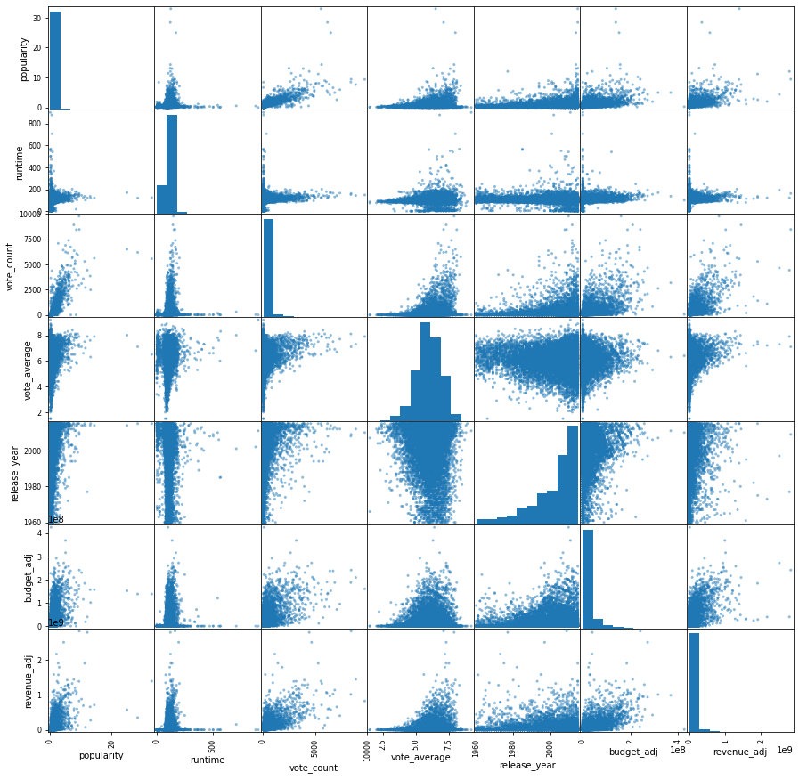

```python
# quick visualization of each features and how they relate to each other
# Histograms show how the features are distributed across the range of their values. This shows if a feature is skewed or normal
# Scatterplots shows the relationship between two features in the dataframe. Tells if there is a relationship

pd.plotting.scatter_matrix(df, figsize = (15,15));
```

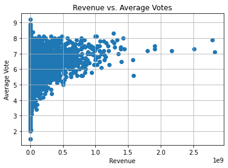

```python
# Function to make scatter diagrams used in investigating the relationship between variables of interest.
def scatter_plot(x, y, title, xlabel, ylabel):
    plt.scatter(x, y)
    plt.xlabel(xlabel)
    plt.ylabel(ylabel)
    plt.title(title)
    plt.grid(True)
    plt.show()


# A plot of revenue_adj vs. vote_average to better visualize their observed relationship
scatter_plot(df.revenue_adj, df.vote_average, 'Revenue vs. Average Votes', 'Revenue', 'Average Vote')
```

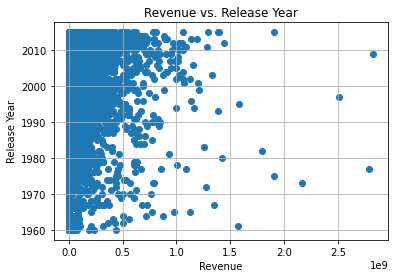

```python
# A plot of revenue_adj vs. release_year to better visualize their observed relationship
scatter_plot(df.revenue_adj, df.release_year, 'Revenue vs. Release Year', 'Revenue', 'Release Year')
```

## References

1. https://www.stackoverflow.com
2. https://www.codegrepper.com/
3. https://datatofish.com/
4. https://www.geeksforgeeks.org/
5. https://www.w3schools.com/
6. https://github.com/adam-p/markdown-here/wiki/Markdown-Cheatsheet
7. Udacity datascience nanodegree materials